# HW3 Solution

Rick Farouni

Oct 1st, 2016

Load required libraries

```r
library(lavaan)
library(semPlot)
```

### EX 1 (a + b)

The following explanation contains material that wasn’t covered at the time when the assignment was handed out, but you should pay attention to it since it provides a big picture for all the models that will be covered in the course.

We can use the *lisrelModel* function (one way to find out about it is through a Google search. Look [here](http://sachaepskamp.com/semPlot/examples) for examples) in the *semPlot* package to plot the path diagram for the model. We just need to feed the function the matrices with a 1 specifiying a free parameter and zero for fixed parameter. Here is the code:

```r
endogen_N <- 3 # number of endogenous observed variables
exogen_N <- 1 # number of exogenous observed variables
# Beta 3x3 matrix:
Beta <- matrix(c(0, 0, 0,
                 1, 0, 0,
                 1, 1, 0),
                nrow = endogen_N,
                ncol = endogen_N,
                byrow = TRUE)

# Gamma 3x1 matrix :
Gamma <- matrix(c(1, 1, 1),
                nrow = endogen_N ,
                ncol = exogen_N )

# Psi 3x3 diagonal matrix :
Psi <- diag(1,
            nrow = endogen_N,
            ncol = endogen_N)

# Phi 1x1 diagonal matrix :
Phi <- diag(1, 1, 1)

# Lambda identity matrices :
Lambda_x <- diag(1, exogen_N, exogen_N)
Lambda_y <- diag(1, endogen_N, endogen_N)

# Combine model:
mod <- lisrelModel(LY = Lambda_y,
                   PS = Psi,
                   BE = Beta,
                   manNamesEndo = c("IQ", "nAch", "GPA"),
                   LX = Lambda_x,
                   PH = Phi,
                   GA = Gamma,
                   manNamesExo = "SES")
```

We can print out the matrices first

```r
Beta
```

```
     [,1] [,2] [,3]
[1,]    0    0    0
[2,]    1    0    0
[3,]    1    1    0
```

```r
Gamma
```

```
     [,1]
[1,]    1
[2,]    1
[3,]    1
```

```r
Psi
```

```
     [,1] [,2] [,3]
[1,]    1    0    0
[2,]    0    1    0
[3,]    0    0    1
```

```r
Phi
```

```
     [,1]
[1,]    1
```

```r
Lambda_x
```

```
     [,1]
[1,]    1
```

```r
Lambda_y
```

```
     [,1] [,2] [,3]
[1,]    1    0    0
[2,]    0    1    0
[3,]    0    0    1
```

Here is the plot. Do you notice something unusual about the graph?

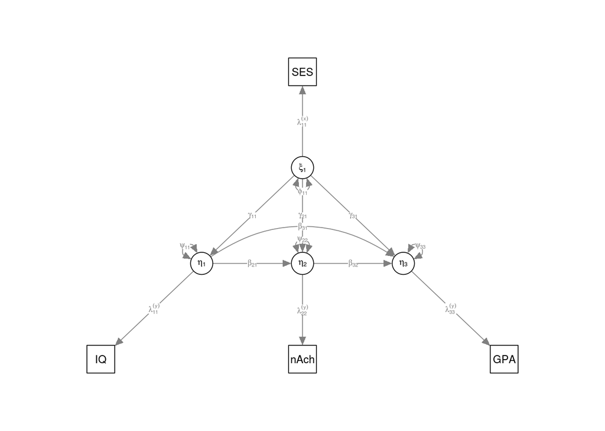

```r
# Plot path diagram:
semPaths(mod,
         as.expression = c("nodes", "edges"),
         sizeMan = 5,  # adjust size of boxes
         sizeInt = 1,
         sizeLat = 4)
```

Alternatively, we can plot a simplified path diagram without Greek letters like this

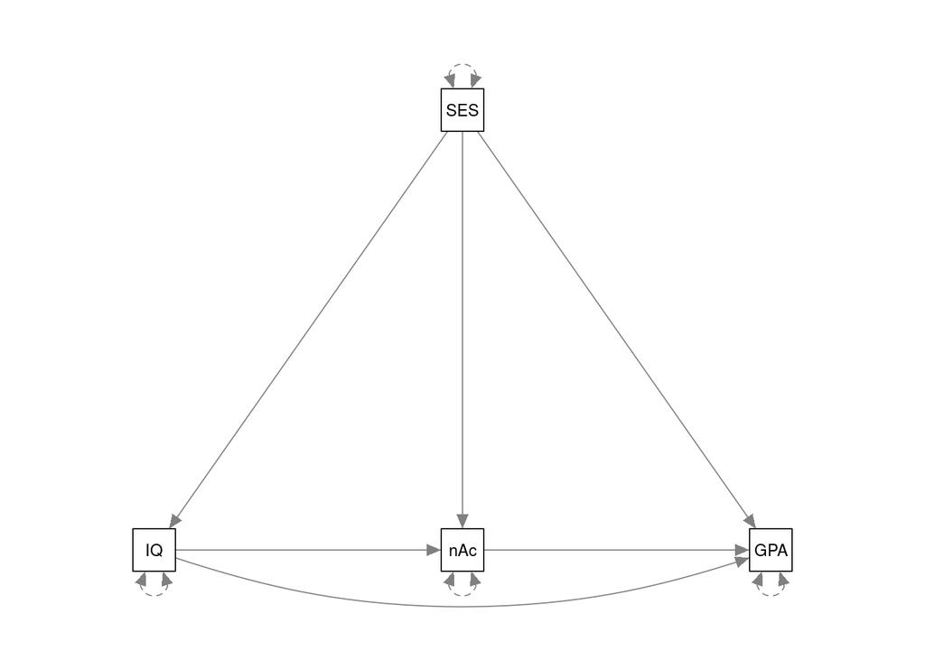

```r
# Specify model
SES_model <- '
   # regressions
     IQ ~ SES
     nAch ~ SES + IQ
     GPA ~ SES + IQ + nAch '

semPaths(SES_model ,
         "eq",
         layout = "tree")
```

### EX 1 (c)

First assign the summarized data to a character vector and convert it to a full symmetric covariance/correlation matrix with names

```r
# SES, IQ and Need Achievement data

SES_lower <- '
 1
.30   1
.41 .16   1
.33 .57 .50   1'

# Sample size
N3 <- 306
SES_cor <- getCov(SES_lower,
                  names = c("SES", "IQ", "nAch", "GPA"))
```

Fit the model

```r
SES_model_fit <- sem(SES_model,
           sample.cov = SES_cor,
           sample.nobs = N3)
```

```
Found more than one class "Model" in cache; using the first, from namespace 'lavaan'
```

Print a summary of the model estimates. Don’t forget to add the *rsquare* option to print out the squared multiple correlations. We can also output the list of model matrices.

```r
summary(SES_model_fit , rsquare = TRUE)
```

```
lavaan (0.5-21) converged normally after  15 iterations

  Number of observations                           306

  Estimator                                         ML
  Minimum Function Test Statistic                0.000
  Degrees of freedom                                 0

Parameter Estimates:

  Information                                 Expected
  Standard Errors                             Standard

Regressions:
                   Estimate  Std.Err  z-value  P(>|z|)
  IQ ~
    SES               0.300    0.055    5.501    0.000
  nAch ~
    SES               0.398    0.055    7.285    0.000
    IQ                0.041    0.055    0.745    0.457
  GPA ~
    SES               0.009    0.046    0.199    0.842
    IQ                0.501    0.043   11.763    0.000
    nAch              0.416    0.045    9.348    0.000

Variances:
                   Estimate  Std.Err  z-value  P(>|z|)
   .IQ                0.907    0.073   12.369    0.000
   .nAch              0.828    0.067   12.369    0.000
   .GPA               0.502    0.041   12.369    0.000

R-Square:
                   Estimate
    IQ                0.090
    nAch              0.170
    GPA               0.496
```

```r
(modelEst1 <- lavInspect(SES_model_fit, "est"))
```

```
$lambda
     IQ nAch GPA SES
IQ    1    0   0   0
nAch  0    1   0   0
GPA   0    0   1   0
SES   0    0   0   1

$theta
     IQ nAch GPA SES
IQ   0
nAch 0  0
GPA  0  0    0
SES  0  0    0   0

$psi
     IQ    nAch  GPA   SES
IQ   0.907
nAch 0.000 0.828
GPA  0.000 0.000 0.502
SES  0.000 0.000 0.000 0.997

$beta
        IQ  nAch GPA   SES
IQ   0.000 0.000   0 0.300
nAch 0.041 0.000   0 0.398
GPA  0.501 0.416   0 0.009
SES  0.000 0.000   0 0.000
```

Note that in lavaan the psi matrix corresponds to the following compound matrix in the notes

$$\begin{bmatrix}
\boldsymbol \Psi & \mathbf 0\\
\mathbf 0 & \boldsymbol \Phi
\end{bmatrix}$$

and the beta matrix to

$$\begin{bmatrix}
\mathbf B & \boldsymbol \Gamma\\
\mathbf 0 & \mathbf 0
\end{bmatrix}$$

This is how to extract them

```r
(Psi   <- modelEst1$psi[1:3, 1:3])
```

```
        IQ  nAch   GPA
IQ   0.907 0.000 0.000
nAch 0.000 0.828 0.000
GPA  0.000 0.000 0.502
```

```r
(Phi   <- modelEst1$psi[4, 4])
```

```
[1] 0.997
```

```r
(Beta  <- modelEst1$beta[1:3, 1:3])
```

```
         IQ  nAch GPA
IQ   0.0000 0.000   0
nAch 0.0407 0.000   0
GPA  0.5007 0.416   0
```

```r
(Gamma <- modelEst1$beta[1:3, 4])
```

```
     IQ    nAch     GPA
0.30000 0.39780 0.00919
```

## EX 2

Assign the summarized data to a character vector

```r
# Social status, actual and perceived income data
income_lower <- '
 1.0000
 0.3670  1.0000
 0.5103  0.4310  1.0000
 0.3633  0.1840  0.2772  1.0000
 0.1574  0.2819  0.2311  0.2921  1.0000'

# Sample size
N4 <- 432
```

Convert to a full symmetric covariance/correlation matrix with names

```r
income_cor <- getCov(income_lower,
                       names = c("subj_income",
                                 "subj_prestige",
                                 "subj_status",
                                 "actual_income",
                                 "actual_prestige"))
```

Specify model

```r
income_model <- '
   # regressions
     subj_income ~ actual_income + subj_prestige
     subj_prestige ~ actual_prestige + subj_income
     subj_status ~ subj_income + subj_prestige
   # correlations
     actual_income ~~ actual_prestige
     subj_income ~~ subj_prestige
     subj_status  ~~ subj_prestige
     subj_status  ~~ subj_income'
```

Note that the “*actual_income ~~ actual_prestige*” is not really needed. Do you know why?(hint: think regression). Now, we can fit the model and print a summary of the model estimates.

```r
income_model_fit <- sem(income_model,
           sample.cov = income_cor,
           sample.nobs = N4)
summary(income_model_fit,
        rsquare = TRUE)
```

```
lavaan (0.5-21) converged normally after  44 iterations

  Number of observations                           432

  Estimator                                         ML
  Minimum Function Test Statistic                0.000
  Degrees of freedom                                 0
  Minimum Function Value               0.0000000000000

Parameter Estimates:

  Information                                 Expected
  Standard Errors                             Standard

Regressions:
                   Estimate  Std.Err  z-value  P(>|z|)
  subj_income ~
    actual_income     0.322    0.054    5.992    0.000
    subj_prestige     0.225    0.178    1.260    0.208
  subj_prestige ~
    actual_prestig    0.231    0.048    4.818    0.000
    subj_income       0.320    0.131    2.449    0.014
  subj_status ~
    subj_income       0.485    0.165    2.940    0.003
    subj_prestige     0.549    0.201    2.731    0.006

Covariances:
                   Estimate  Std.Err  z-value  P(>|z|)
  actual_income ~~
    actual_prestig    0.291    0.050    5.828    0.000
 .subj_income ~~
   .subj_prestige    -0.173    0.188   -0.918    0.359
 .subj_prestige ~~
   .subj_status      -0.239    0.166   -1.438    0.150
 .subj_income ~~
   .subj_status      -0.109    0.133   -0.822    0.411

Variances:
                   Estimate  Std.Err  z-value  P(>|z|)
   .subj_income       0.780    0.061   12.843    0.000
   .subj_prestige     0.812    0.055   14.680    0.000
   .subj_status       0.762    0.101    7.531    0.000
    actual_income     0.998    0.068   14.697    0.000
    actual_prestig    0.998    0.068   14.697    0.000

R-Square:
                   Estimate
    subj_income       0.218
    subj_prestige     0.186
    subj_status       0.236
```

We can also output a list of model matrices

```r
(modelEst2 <- lavInspect(income_model_fit, "est"))
```

```
$lambda
                sbj_nc sbj_pr sbj_st actl_n actl_p
subj_income          1      0      0      0      0
subj_prestige        0      1      0      0      0
subj_status          0      0      1      0      0
actual_income        0      0      0      1      0
actual_prestige      0      0      0      0      1

$theta
                sbj_nc sbj_pr sbj_st actl_n actl_p
subj_income     0
subj_prestige   0      0
subj_status     0      0      0
actual_income   0      0      0      0
actual_prestige 0      0      0      0      0

$psi
                sbj_nc sbj_pr sbj_st actl_n actl_p
subj_income      0.780
subj_prestige   -0.173  0.812
subj_status     -0.109 -0.239  0.762
actual_income    0.000  0.000  0.000  0.998
actual_prestige  0.000  0.000  0.000  0.291  0.998

$beta
                sbj_nc sbj_pr sbj_st actl_n actl_p
subj_income      0.000  0.225      0  0.322  0.000
subj_prestige    0.320  0.000      0  0.000  0.231
subj_status      0.485  0.549      0  0.000  0.000
actual_income    0.000  0.000      0  0.000  0.000
actual_prestige  0.000  0.000      0  0.000  0.000
```

Note that in lavaan the psi matrix corresponds to the following compound matrix in the notes

$$\begin{bmatrix}
\boldsymbol \Psi & \mathbf 0\\
\mathbf 0 & \boldsymbol \Phi
\end{bmatrix}$$

and the beta matrix to

$$\begin{bmatrix}
\mathbf B & \boldsymbol \Gamma\\
\mathbf 0 & \mathbf 0
\end{bmatrix}$$

This is how to extract them

```r
(Psi   <- modelEst2$psi[1:3, 1:3])
```

```
              subj_income subj_prestige subj_status
subj_income         0.780        -0.173      -0.109
subj_prestige      -0.173         0.812      -0.239
subj_status        -0.109        -0.239       0.762
```

```r
(Phi   <- modelEst2$psi[4:5, 4:5])
```

```
                actual_income actual_prestige
actual_income           0.998           0.291
actual_prestige         0.291           0.998
```

```r
(Beta  <- modelEst2$beta[1:3, 1:3])
```

```
              subj_income subj_prestige subj_status
subj_income         0.000         0.225           0
subj_prestige       0.320         0.000           0
subj_status         0.485         0.549           0
```

```r
(Gamma <- modelEst2$beta[1:3, 4:5])
```

```
              actual_income actual_prestige
subj_income           0.322           0.000
subj_prestige         0.000           0.231
subj_status           0.000           0.000
```

Plot the path diagram

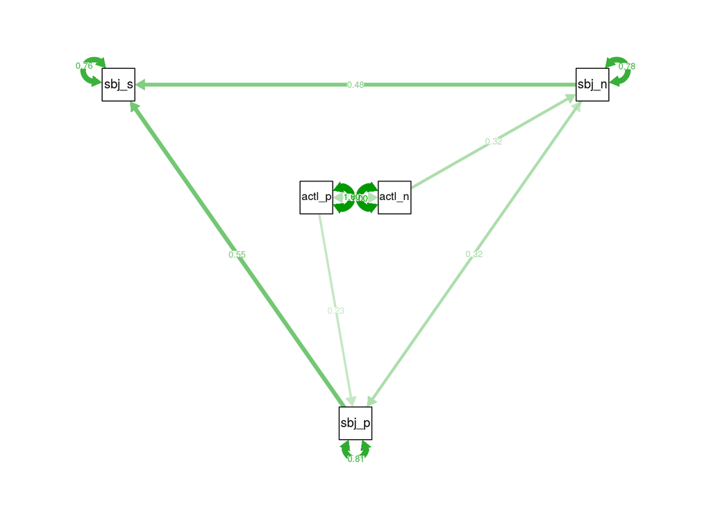

```r
semPaths(income_model_fit,
         "par",
         layout = "circle")
```